# act_report

## WeRateDogs Twitter Project Act Report

The aim of this project was to to analyse the WeRateDogs twitter posts upto August 1,2017.

The datasets have gone through the following steps:

Step 1: Gathering data

Step 2: Assesing data

Step 3: Cleaning data

Step 4: Storing data

Step 5: Analyzing and visualization of data

The steps above have been clearly covered in-depth in the wrangle_report in this project.

This act report will now cover the findings found in the Analysis and Visualization step.

1. There most common name is Charlie while Lucy, Oliver and Cooper are the second common names. It seems that more dogs posted in the twitter account are male.

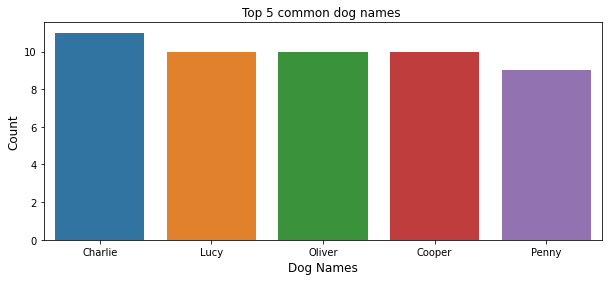

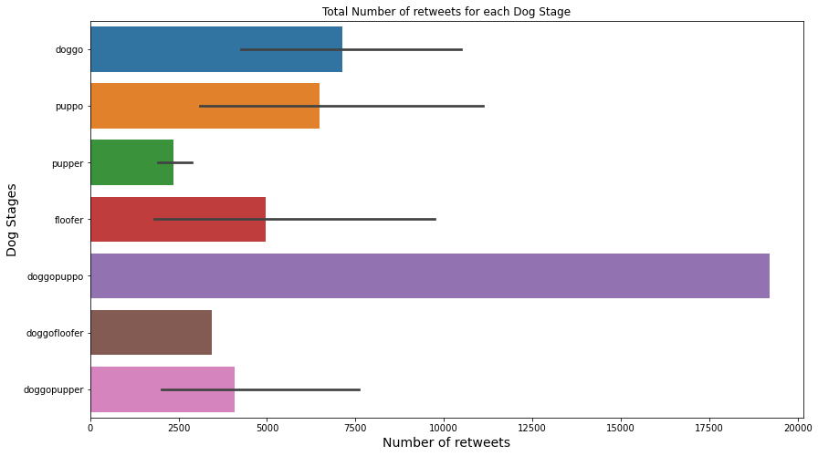

1. The most liked dog stage is doggopuppo followed by puppo

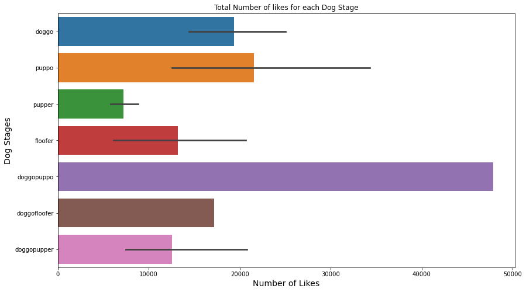